# DNA/RNA Dynamics Project

## Student: Amrou Abas

### ID: 0000996952

### - Step 3 address: 18756452

### - Step 5 detPvalue threshold: 0.05

### - Step 7 Normalization procedure: preprocessNoob

### - Step 9 Test: t-test

## 1. Load raw data with minfi and create an object called RGset storing the RGChannelSet object.

At this point in the beginning, from what we see in our data below, we have raw data of samples, each sample with the slide number and the array name, for each sample there are two files, one for the green channel and one for the red. Exploring the Samplesheet_report_2021.csv file. It divides the Samples into samples with Down’s Syndrome (DS) and samples carrying Wild Type (WT):

❖ Loading **minfi** :

```r
library(minfi)
```

❖ Disable messages upon loading the package:

```r
vignette("minfi")
```

```
## starting httpd help server ... done
```

❖ Setting the working directory:

```r
setwd('C:/Users/Utente/Desktop/DRDModule2/report/')
```

❖ Loading the csv version of the sample sheet to check it:

```r
SampleSheet <- read.table("C:/Users/Utente/Desktop/DRDModule2/report/Input_Data/Samplesheet_report_2021.csv",sep=",",header=T)
SampleSheet
```

```
##   Sample_Name Group Age Sex      Slide  Array          Basename
## 1        1028    DS  38   0 5775278051 R01C02 5775278051_R01C02
## 2        1038    DS  37   1 5775278078 R01C01 5775278078_R01C01
## 3        3038    WT  46   0 5775278078 R02C01 5775278078_R02C01
## 4        3046    WT  36   1 5775278078 R02C02 5775278078_R02C02
## 5        1052    DS  35   1 5775278078 R04C02 5775278078_R04C02
## 6        1016    DS  43   0 5930514034 R01C02 5930514034_R01C02
## 7        3029    WT  35   0 5930514035 R06C02 5930514035_R06C02
## 8        3037    WT  38   1 5930514054 R06C01 5930514054_R06C01
```

❖ Reading the sample sheet:

```r
baseDir <- ("C:/Users/Utente/Desktop/DRDModule2/report/Input_data")
targets <- read.metharray.sheet(baseDir)
```

```
## [read.metharray.sheet] Found the following CSV files:
```

```
## [1] "C:/Users/Utente/Desktop/DRDModule2/report/Input_data/Samplesheet_report_2021.csv"
```

```r
targets
```

```
##   Sample_Name Group Age Sex      Slide  Array
## 1        1028    DS  38   0 5775278051 R01C02
## 2        1038    DS  37   1 5775278078 R01C01
## 3        3038    WT  46   0 5775278078 R02C01
## 4        3046    WT  36   1 5775278078 R02C02
## 5        1052    DS  35   1 5775278078 R04C02
## 6        1016    DS  43   0 5930514034 R01C02
## 7        3029    WT  35   0 5930514035 R06C02
## 8        3037    WT  38   1 5930514054 R06C01
##                                                                 Basename
## 1 C:/Users/Utente/Desktop/DRDModule2/report/Input_data/5775278051_R01C02
## 2 C:/Users/Utente/Desktop/DRDModule2/report/Input_data/5775278078_R01C01
## 3 C:/Users/Utente/Desktop/DRDModule2/report/Input_data/5775278078_R02C01
## 4 C:/Users/Utente/Desktop/DRDModule2/report/Input_data/5775278078_R02C02
## 5 C:/Users/Utente/Desktop/DRDModule2/report/Input_data/5775278078_R04C02
## 6 C:/Users/Utente/Desktop/DRDModule2/report/Input_data/5930514034_R01C02
## 7 C:/Users/Utente/Desktop/DRDModule2/report/Input_data/5930514035_R06C02
## 8 C:/Users/Utente/Desktop/DRDModule2/report/Input_data/5930514054_R06C01
```

Something to note is that the file targets includes similar data to the SampleSheet file except that minfi puts the entire path to the file (that is, when using **read.metharray.sheet()** function).

❖ Create the RGset channel object:

```r
RGset <- read.metharray.exp(targets = targets)
```

[output not shown]

```r
save(RGset,file="RGset.RData")
RGset
```

```
## class: RGChannelSet
## dim: 622399 8
## metadata(0):
## assays(2): Green Red
## rownames(622399): 10600313 10600322 ... 74810490 74810492
## rowData names(0):
## colnames(8): 5775278051_R01C02 5775278078_R01C01 ... 5930514035_R06C02
##   5930514054_R06C01
## colData names(8): Sample_Name Group ... Basename filenames
## Annotation
##   array: IlluminaHumanMethylation450k
##   annotation: ilmn12.hg19
```

Saying that the targets file that we want to use is the object which has the name **targets** and saving it. Obtaining information about it, we check the class and it is indeed **RGChannelSet** and the annotation is ilmn12.hg19.

## 2- Create the dataframes Red and Green to store the red and green fluorescences respectively.

❖ We will need to apply the below command to know the accessor functions that are specific to deal with such kind of data:

```r
??RGChannel
```

❖ Using the accessor functions to create red and green data frames.

```r
Green <- data.frame(getGreen(RGset))
Red <- data.frame(getRed(RGset))
head(Red)
```

```
##          X5775278051_R01C02 X5775278078_R01C01 X5775278078_R02C01
## 10600313                651                585                603
## 10600322               1978               2073               1840
## 10600328               1984               1586               1420
## 10600336              17493              15212              16924
## 10600345               3273               2905               3198
## 10600353               1412               1190               1228
##          X5775278078_R02C02 X5775278078_R04C02 X5930514034_R01C02
## 10600313                630                549                441
## 10600322               2096               2102               1383
## 10600328               1655               1354               3456
## 10600336              17777              17026              16169
## 10600345               3232               3381               3424
## 10600353               1108               1000               1164
##          X5930514035_R06C02 X5930514054_R06C01
## 10600313                606                492
## 10600322               2315               2503
## 10600328               2540               2859
## 10600336              19048              19481
## 10600345               3595               3996
## 10600353               1136               1184
```

```r
head(Green)
```

```
##          X5775278051_R01C02 X5775278078_R01C01 X5775278078_R02C01
## 10600313                403                302                278
## 10600322               7626               6486               6667
## 10600328               2306               1974               1995
## 10600336               1740               1284               1456
## 10600345               3228               2742               3590
## 10600353               3709               3213               3790
##          X5775278078_R02C02 X5775278078_R04C02 X5930514034_R01C02
## 10600313                264                344                210
## 10600322               7185               7945               6896
## 10600328               1938               1878               2954
## 10600336               1484               2060               1152
## 10600345               3112               3231               2975
## 10600353               3199               3493               2973
##          X5930514035_R06C02 X5930514054_R06C01
## 10600313                350                399
## 10600322               9709              10572
## 10600328               2806               3006
## 10600336               1617               1725
## 10600345               4530               3979
## 10600353               3983               3664
```

The rows in the two data frames stand for addresses (and columns for samples), and hence we got the fluorescences of the beads one by one.

## 3- Fill the following table: what are the Red and Green fluorescences for the address assigned to you? Optional: check in the manifest file if the address corresponds to a Type I or a Type II probe and, in case of Type I probe, report its color.

❖ Uploading the manifest file (The clean version of it, already removing rs and control probes):

```r
load('C:/Users/Utente/Desktop/DRDModule2/lesson2/Illumina450Manifest_clean.RData')
```

❖ Check the probe having address 18756452:

```r
Illumina450Manifest_clean[Illumina450Manifest_clean$AddressA_ID=="18756452",]
```

```
##        IlmnID       Name AddressA_ID
## 41 cg01523029 cg01523029    18756452
##                                      AlleleA_ProbeSeq AddressB_ID
## 41 CRTCTTAAACACCTTACRTTTCTAAAATAAACCTACTAAAAACAAACACC
##    AlleleB_ProbeSeq Infinium_Design_Type Next_Base Color_Channel
## 41                                    II
##                                                                                                                Forward_Sequence
## 41 CGCCGCGAACCCGTCTTAAGCACCTTGCGTTTCTGGGGTGAGCCTGCTGGAAACAGGCAC[CG]AGAGCAGGGGTGGTTCAATGGCTGGTAATGGCATACAGATTCCCCGTCCTCCAGGGACGT
##    Genome_Build CHR MAPINFO                                          SourceSeq
## 41           37   Y 9234365 CGGTGCCTGTTTCCAGCAGGCTCACCCCAGAAACGCAAGGTGCTTAAGAC
##    Chromosome_36 Coordinate_36 Strand Probe_SNPs Probe_SNPs_10 Random_Loci
## 41             Y       9294365      R                                   NA
##    Methyl27_Loci UCSC_RefGene_Name UCSC_RefGene_Accession UCSC_RefGene_Group
## 41            NA             TSPY4           NM_001164471               Body
##    UCSC_CpG_Islands_Name Relation_to_UCSC_CpG_Island Phantom DMR Enhancer
## 41  chrY:9234221-9235400                      Island                   NA
##           HMM_Island Regulatory_Feature_Name Regulatory_Feature_Group DHS
## 41 Y:9293666-9296814                                                   NA
```

There is AddressA_ID with the code 18756452, associated to the probe cg01523029.

```r
Illumina450Manifest_clean[Illumina450Manifest_clean$AddressB_ID=="18756452",]
```

```
##  [1] IlmnID                      Name
##  [3] AddressA_ID                 AlleleA_ProbeSeq
##  [5] AddressB_ID                 AlleleB_ProbeSeq
##  [7] Infinium_Design_Type        Next_Base
##  [9] Color_Channel               Forward_Sequence
## [11] Genome_Build                CHR
## [13] MAPINFO                     SourceSeq
## [15] Chromosome_36               Coordinate_36
## [17] Strand                      Probe_SNPs
## [19] Probe_SNPs_10               Random_Loci
## [21] Methyl27_Loci               UCSC_RefGene_Name
## [23] UCSC_RefGene_Accession      UCSC_RefGene_Group
## [25] UCSC_CpG_Islands_Name       Relation_to_UCSC_CpG_Island
## [27] Phantom                     DMR
## [29] Enhancer                    HMM_Island
## [31] Regulatory_Feature_Name     Regulatory_Feature_Group
## [33] DHS
## <0 righe> (o 0-length row.names)
```

There is not an addressB_ID with code 18756452. So, 2 probe types in single bead, single address (A).

❖ Getting the fluorescences using the Red and green data frames:

```r
Red[rownames(Red)=="18756452",]
```

```
##          X5775278051_R01C02 X5775278078_R01C01 X5775278078_R02C01
## 18756452               7505                980               5765
##          X5775278078_R02C02 X5775278078_R04C02 X5930514034_R01C02
## 18756452                796                267               7755
##          X5930514035_R06C02 X5930514054_R06C01
## 18756452               8602                311
```

```r
Green[rownames(Green)=="18756452",]
```

```
##          X5775278051_R01C02 X5775278078_R01C01 X5775278078_R02C01
## 18756452              11047               2817              10017
##          X5775278078_R02C02 X5775278078_R04C02 X5930514034_R01C02
## 18756452               2742                260              10400
##          X5930514035_R06C02 X5930514054_R06C01
## 18756452              13375                322
```

❖ In a table:

```r
red_column <- data.frame(t(Red[rownames(Red)=="18756452",]))
green_column <- data.frame(t(Green[rownames(Green)=="18756452",]))

#combining the two columns:

combined <- cbind(red_column,green_column)
names(combined)[1] <- "Red Fluor"
names(combined)[2] <- "Green Fluor"
combined
```

```
##                    Red Fluor Green Fluor
## X5775278051_R01C02      7505       11047
## X5775278078_R01C01       980        2817
## X5775278078_R02C01      5765       10017
## X5775278078_R02C02       796        2742
## X5775278078_R04C02       267         260
## X5930514034_R01C02      7755       10400
## X5930514035_R06C02      8602       13375
## X5930514054_R06C01       311         322
```

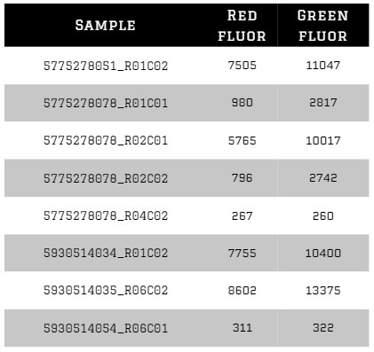

❖ Checking if the file corresponds to which type using the function getProbeInfo() as kind of a proof to what is expected (that we have type II only).

❖ First creating dataframes for both types I and II:

```r
df_I <- data.frame(getProbeInfo(RGset, type = "I"))
df_II <- data.frame(getProbeInfo(RGset, type = "II"))
```

❖ Checking each address:

```r
df_I[df_I$AddressA==18756452,]
```

```
## [1] Name      AddressA  AddressB  Color     NextBase  ProbeSeqA ProbeSeqB
## [8] nCpG
## <0 righe> (o 0-length row.names)
```

```r
df_I[df_I$AddressB==18756452,]
```

```
## [1] Name      AddressA  AddressB  Color     NextBase  ProbeSeqA ProbeSeqB
## [8] nCpG
## <0 righe> (o 0-length row.names)
```

```r
df_II[df_II$AddressA==18756452,]
```

```
##          Name AddressA                                          ProbeSeqA nCpG
## 36 cg01523029 18756452 CRTCTTAAACACCTTACRTTTCTAAAATAAACCTACTAAAAACAAACACC    2
```

```r
df_II[df_II$AddressB==18756452,]
```

```
## [1] Name      AddressA  ProbeSeqA nCpG
## <0 righe> (o 0-length row.names)
```

In the above four codes, only the third one produced the result, which coincides with our precedent analysis also.

## 4- Create the object MSet.raw

```r
MSet.raw <- preprocessRaw(RGset)
save(MSet.raw,file="MSet_raw.RData")
```

Simply we converted the RGset object into Methylset object, which is a summary of the relevant information of the RGChannelSet object, it takes the fluorensces of the correct addresses and associate them to methylation or unmethylation signal, here the rows are the probes, and columns are the sample.

❖ If we want to get the methylation and unmethylation signals:

```r
getManifest(RGset)
```

```
## IlluminaMethylationManifest object
## Annotation
##   array: IlluminaHumanMethylation450k
## Number of type I probes: 135476
## Number of type II probes: 350036
## Number of control probes: 850
## Number of SNP type I probes: 25
## Number of SNP type II probes: 40
```

```r
Meth <- getMeth(MSet.raw)
Unmeth <- getUnmeth(MSet.raw)
head(Meth)
```

```
##            5775278051_R01C02 5775278078_R01C01 5775278078_R02C01
## cg00050873             11034              1980             10589
## cg00212031               916               395               428
## cg00213748              2472               492              2509
## cg00214611               586               385               366
## cg00455876              4393               644              3518
## cg01707559               626               556               656
##            5775278078_R02C02 5775278078_R04C02 5930514034_R01C02
## cg00050873              1853               302             12290
## cg00212031               399               299               216
## cg00213748               348               300              2100
## cg00214611               321               377               221
## cg00455876               465               277              3640
## cg01707559               501               453               767
##            5930514035_R06C02 5930514054_R06C01
## cg00050873             14516               276
## cg00212031               645               358
## cg00213748              2529               280
## cg00214611               367               346
## cg00455876              4919               335
## cg01707559               603               507
```

```r
head(Unmeth)
```

```
##            5775278051_R01C02 5775278078_R01C01 5775278078_R02C01
## cg00050873              1217               434              1047
## cg00212031              8599               396              7746
## cg00213748               682               412               432
## cg00214611              7425               477              7759
## cg00455876              1038               631               811
## cg01707559              9262               941              9543
##            5775278078_R02C02 5775278078_R04C02 5930514034_R01C02
## cg00050873               398               368              1484
## cg00212031               355               269              7864
## cg00213748               335               338               356
## cg00214611               401               305              6515
## cg00455876               486               428               734
## cg01707559               836               626              9202
##            5930514035_R06C02 5930514054_R06C01
## cg00050873              1933               352
## cg00212031              8538               325
## cg00213748               441               335
## cg00214611              7355               354
## cg00455876               695               417
## cg01707559             10830               811
```

Here above, the result shows methylation/unmethylation fluorescence signals and not regarding a color in particular.

## 5- Perform the following quality checks and provide a brief comment to each step:

# • check the intensity of negative controls using minfi.

# • calculate detection pValues; for each sample, how many probes have a detection p-value higher than the threshold assigned to each student?

❖ QCplot using the function getQC:

```r
qc <- getQC(MSet.raw)
qc
```

```
## DataFrame with 8 rows and 2 columns
##                        mMed      uMed
##                   <numeric> <numeric>
## 5775278051_R01C02   11.6957   11.7322
## 5775278078_R01C01   11.4419   11.5098
## 5775278078_R02C01   11.5774   11.6170
## 5775278078_R02C02   11.6152   11.7065
## 5775278078_R04C02   11.7237   11.6662
## 5930514034_R01C02   11.5038   11.6416
## 5930514035_R06C02   11.9436   11.9035
## 5930514054_R06C01   11.9326   11.8807
```

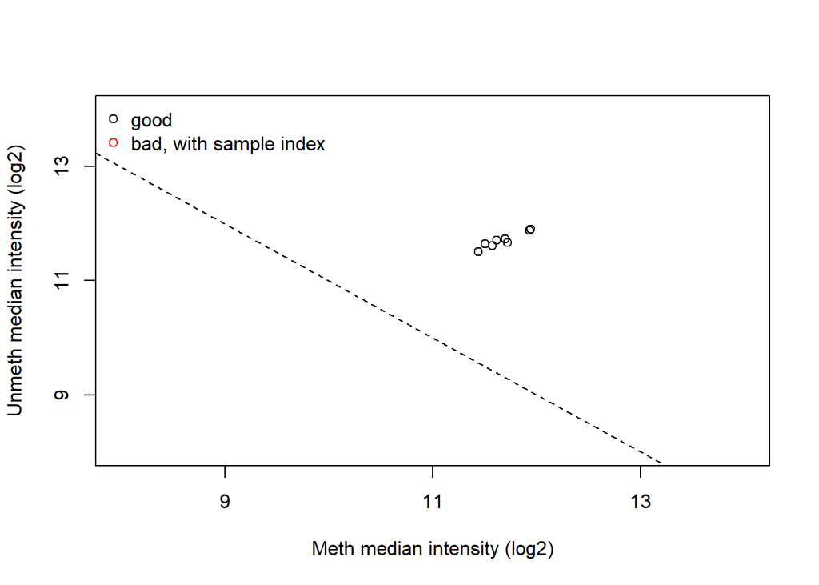

```r
plotQC(qc)
```

Failed samples are the ones that have low methylation or unmethylation values, as from the above graph and in the above steps, we first got the median of methylation and unmethylation channels for each sample, then we plotted for all the probes the median of methylation and unmethylation signal intensities.

All the samples shown here have sufficient fluorescence signal intensities and hence they are done in a good manner.

❖ Check the intensity of negative controls using **minfi** :

This kind of probes usually should not hybridise and are used to measure the amount of background signal in the array, to assess technical variability, so it is important for assessing methylation levels in a correct way.

Getting the number of negative controls first (restricting our search to only probes of the type “Control”):

```r
df_TypeControl <- data.frame(getProbeInfo(RGset, type = "Control"))
dim(df_TypeControl[df_TypeControl$Type=="NEGATIVE",])
```

```
## [1] 613   4
```

They are 613 negative controls, and now plotting their intensities using the function controlStripPlot:

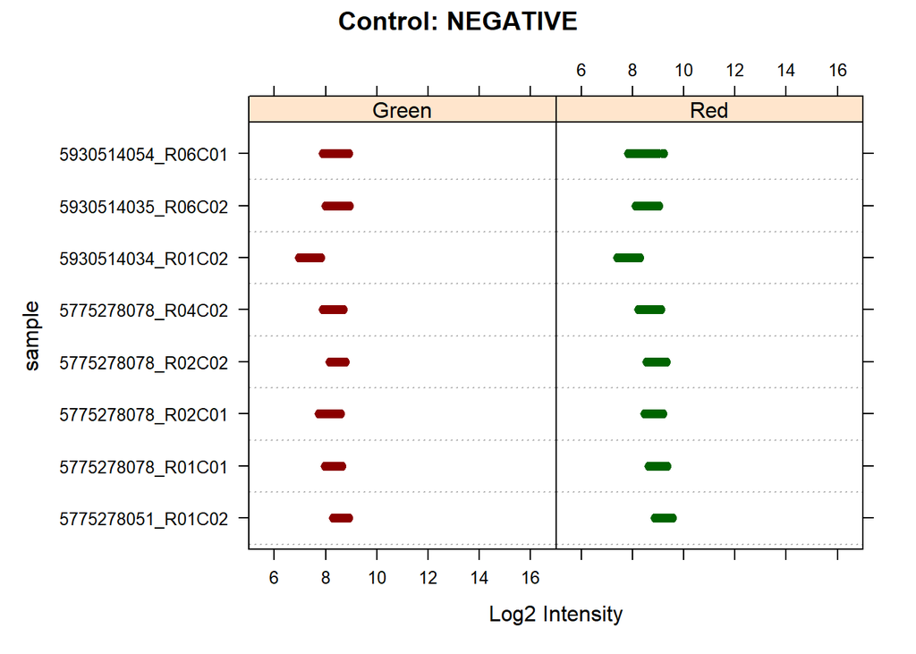

```r
controlStripPlot(RGset, controls="NEGATIVE")
```

We can conclude that all the 613 beads have fluorescence signals lower than 10 **(log2(1000))**, thus one can say that the background value is significantly lower than the cutoff threshold that was portrayed in the QC graph, and the template quality prior to the bisulfite conversion is good as well.

❖ Calculate detection pValues; for each sample, how many probes have a detection p-value higher than the threshold assigned to each student?

In this regard we will use **detectionP()** function, which provided by **minfi** and is used to detect the failed positions (i.e: the positions that report high background value compared to real signal and hence can be considered as noise to the real signal), using a p-value of 0.05 above which the p-value is considered insignificant and the positions should not be considered reliable.

First of all, creating a matrix of detection of pValues where the rows are the probes and the columns are the samples detectionP:

```r
detP <- detectionP(RGset)
save(detP,file="detP.RData")
load("detP.RData")
```

Collecting all the failed probes in a logical matrix for all the probes, classifying the probes of them meeting the criteria of less than 0.05 threshold:

```r
failed <- detP>0.05
table(failed)
```

```
## failed
##   FALSE    TRUE
## 3881163    2933
```

The code above resulted in classifying the data into 3881163 pValues that are sufficient to trust the fluorescence values associated to the probes, and 2933 values that happen to have high pValues and should be discarded.

Classifying them on whether they should be trusted or not:

```r
summary(failed)
```

```
##  5775278051_R01C02 5775278078_R01C01 5775278078_R02C01 5775278078_R02C02
##  Mode :logical     Mode :logical     Mode :logical     Mode :logical
##  FALSE:485275      FALSE:484932      FALSE:485248      FALSE:484916
##  TRUE :237         TRUE :580         TRUE :264         TRUE :596
##  5775278078_R04C02 5930514034_R01C02 5930514035_R06C02 5930514054_R06C01
##  Mode :logical     Mode :logical     Mode :logical     Mode :logical
##  FALSE:484919      FALSE:485421      FALSE:485397      FALSE:485055
##  TRUE :593         TRUE :91          TRUE :115         TRUE :457
```

Converting its summary to a dataframe with keeping only the failed row

```r
Q5third <- as.data.frame(apply(failed, 2, summary))
Q5third <- Q5third[row.names(Q5third) %in% c(TRUE),]
```

Reversing columns to rows:

```r
Q5third <- as.data.frame(as.matrix(t(Q5third[,-1])))
Q5third
```

```
##                   TRUE
## 5775278078_R01C01  580
## 5775278078_R02C01  264
## 5775278078_R02C02  596
## 5775278078_R04C02  593
## 5930514034_R01C02   91
## 5930514035_R06C02  115
## 5930514054_R06C01  457
```

Organized in a table:

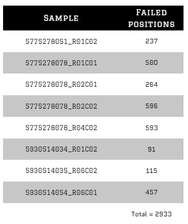

As we see, the number of failed probes that is low considering the whole number of probes, additionally in an additiional next step, we can exclude any potential samples that had exceptionally and significantly higher number of failed positions according to a certain threshold, and another retaining method can be to exclude the probes that performed poorly in all the samples, using the functions **colMeans()** and **rowMeans()** respectively.

Getting the percentage of failed probes across samples:

```r
means_of_columns <- colMeans(failed)
samples_to_be_retained <- means_of_columns<0.05
RGset <- RGset[samples_to_be_retained]

means_of_columns
```

```
## 5775278051_R01C02 5775278078_R01C01 5775278078_R02C01 5775278078_R02C02
##      0.0004881445      0.0011946152      0.0005437559      0.0012275701
## 5775278078_R04C02 5930514034_R01C02 5930514035_R06C02 5930514054_R06C01
##      0.0012213910      0.0001874310      0.0002368634      0.0009412744
```

```r
samples_to_be_retained
```

```
## 5775278051_R01C02 5775278078_R01C01 5775278078_R02C01 5775278078_R02C02
##              TRUE              TRUE              TRUE              TRUE
## 5775278078_R04C02 5930514034_R01C02 5930514035_R06C02 5930514054_R06C01
##              TRUE              TRUE              TRUE              TRUE
```

From what was seen in **means_of_columns**, the percentage of failed probes is low in all the samples, all samples were retained.

Removing any possible probes that failed in a high number of samples(We can decide, for example, to retain only the probes in which <1 % of samples has a bad detection p-value (greater than 0.05, the threshold that we used to calculate the object **failed**)):

```r
means_of_rows <- rowMeans(failed)
probes_to_be_retained <- means_of_rows<0.01 # I chose the threshold here as the one in class
table(probes_to_be_retained)
```

```
## probes_to_be_retained
##  FALSE   TRUE
##   1397 484115
```

There are 1397 probes to be removed and 484115 to be retained.

Selecting the probes that we want to remove potentially and save them for any further potential steps:

```r
probes_to_be_removed <- probes_to_be_retained[probes_to_be_retained==FALSE]
names_probes_to_be_removed <- names(probes_to_be_removed)
save(names_probes_to_be_removed,file="names_probes_to_be_removed.RData")
```

## 6- Calculate raw beta and M values and plot the densities of mean methylation values, dividing the samples in DS and WT (suggestion: subset the beta and M values matrixes in order to retain DS or WT subjects and apply the function mean to the 2 subsets).

First, the beta value represents the percentage of methylation at a given site (Beta=(M/(M+U))), a continous variable between 0 (absent methylation) and 1 (completely methylated), it is heteroscedastic.

While M value is a continous variable which can in principle take on any value on the real line(M=log2(M/U)), it is homoscedastic.

Getting the beta values using **getBeta** accessor function on MethylSet:

```r
beta <- getBeta(MSet.raw)
```

Getting the beta values using **getM** accessor function on MethylSet class object as well:

```r
M <- getM(MSet.raw)
```

Dividing the Beta and M values based being Wild Type or Down’s Syndrome:

```r
beta_WT <- beta[,MSet.raw$Group=="WT"]
beta_DS <- beta[,MSet.raw$Group=="DS"]
M_WT <- M[,MSet.raw$Group=="WT"]
M_DS <- M[,MSet.raw$Group=="DS"]
```

Now, there are NA values that have the beta and M methylation/unmethylation values are equal to zero. and is undefined, we need to filter them out. Since we want to plot the density distribution now, we need to calculate the mean as well as getting rid of NA’s, we can use the function **apply()** :

```r
mean_of_beta_WT <- apply(beta_WT,1,mean,na.rm=T)
mean_of_beta_DS <- apply(beta_DS,1,mean,na.rm=T)
mean_of_M_WT <- apply(M_WT,1,mean,na.rm=T)
mean_of_M_DS <- apply(M_DS,1,mean,na.rm=T)
```

Now we can have the density distribution:

```r
d_mean_of_WT_beta <- density(mean_of_beta_WT)
d_mean_of_DS_beta <- density(mean_of_beta_DS)
d_mean_of_WT_m <- density(mean_of_M_WT)
d_mean_of_DS_m <- density(mean_of_M_DS)
```

Plotting the density distributions:

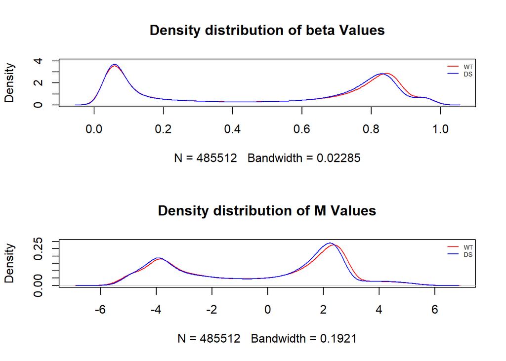

```r
par(mfrow=c(2,1))
plot(d_mean_of_WT_beta,main="Density distribution of beta Values",col="red", ylim=c(0,4))
lines(d_mean_of_DS_beta,col="blue")
legend("topright", legend=c("WT", "DS"), col=c("red", "blue"), lwd=1:1, cex=0.5, bty="n")
plot(d_mean_of_WT_m,main="Density distribution of M Values",col="red", ylim=c(0,0.3))
lines(d_mean_of_DS_m,col="blue")
legend("topright", legend=c("WT", "DS"), col=c("red", "blue"), lwd=1:1, cex=0.5, bty="n")
```

We can see from the observed results that there is a shift towards the left in samples with DS, which means that there are decreased methylation levels with samples with Down’s Syndrome, which might be of clinical importance as an observation.

## 7- Normalize the data using the function assigned to each student (preprocessNoob in here) and compare raw data and normalized data. Produce a plot with 6 panels in which, for both raw and normalized data, you show the density plots of beta mean values according to the chemistry of the probes, the density plot of beta standard deviation values according to the chemistry of the probes and the boxplot of beta values. Provide a short comment regarding the changes you observe.

❖ First, we need to divide the dataframes of beta values according to the chemistry (whether it is Type I or Type II), we can do that throughout the clean version of **Illumina450Manifest**:

```r
df_I <- Illumina450Manifest_clean[Illumina450Manifest_clean$Infinium_Design_Type=="I",]
df_I <- droplevels(df_I)
df_II <- Illumina450Manifest_clean[Illumina450Manifest_clean$Infinium_Design_Type=="II",]
df_II <- droplevels(df_II)
dim(df_I)
```

```
## [1] 135476     33
```

```r
dim(df_II)
```

```
## [1] 350036     33
```

❖ Keep the rows of beta that have the IlmnID in df_I and df_II:

```r
beta_I <- beta[rownames(beta) %in% df_I$IlmnID,]
beta_II <- beta[rownames(beta) %in% df_II$IlmnID,]
```

For each probe in the mean_of_beta_I and mean_of_beta_II matrices, we calculate the mean of beta values across the 8 samples, and then we calculate the density distribution of the 2 vectors of mean values as the following:

```r
mean_of_beta_I <- apply(beta_I,1,mean)
mean_of_beta_II <- apply(beta_II,1,mean)
d_mean_of_beta_I <- density(mean_of_beta_I,na.rm=T)
d_mean_of_beta_II <- density(mean_of_beta_II,na.rm=T)
```

Calculating the standard deviation across the 8 samples and its density distribution:

```r
sd_of_beta_I <- apply(beta_I,1,sd,na.rm=T)
sd_of_beta_II <- apply(beta_II,1,sd,na.rm=T)
d_sd_of_beta_I <- density(sd_of_beta_I,)
d_sd_of_beta_II <- density(sd_of_beta_II)
```

Now we can start to use the **preprocessNoob()** (Noob stands for normal-exponential out-of-band) normalization function, which is a background correction method with dye-bias normalization for Illumina Infinium methylation arrays, and will be put in action as follows:

```r
preprocessNoob_results <- preprocessNoob(RGset)
#Getting the beta values:
preprocessNoob_results_beta <- getBeta(preprocessNoob_results)
```

Now we do the exact same steps for the normalized data:

```r
preprocessNoob_results_beta_I <- preprocessNoob_results_beta[rownames(preprocessNoob_results_beta) %in% df_I$IlmnID,]
preprocessNoob_results_beta_II <- preprocessNoob_results_beta[rownames(preprocessNoob_results_beta) %in% df_II$IlmnID,]
mean_of_preprocessNoob_results_beta_I <- apply(preprocessNoob_results_beta_I,1,mean)
mean_of_preprocessNoob_results_beta_II <- apply(preprocessNoob_results_beta_II,1,mean)
d_mean_of_preprocessNoob_results_beta_I <- density(mean_of_preprocessNoob_results_beta_I,na.rm=T)
d_mean_of_preprocessNoob_results_beta_II <- density(mean_of_preprocessNoob_results_beta_II,na.rm=T)
sd_of_preprocessNoob_results_beta_I <- apply(preprocessNoob_results_beta_I,1,sd)
sd_of_preprocessNoob_results_beta_II <- apply(preprocessNoob_results_beta_II,1,sd)
d_sd_of_preprocessNoob_results_beta_I <- density(sd_of_preprocessNoob_results_beta_I,na.rm=T)
d_sd_of_preprocessNoob_results_beta_II <- density(sd_of_preprocessNoob_results_beta_II,na.rm=T)
```

Plotting the raw data versus the one that is normalized using preprocessNoob:

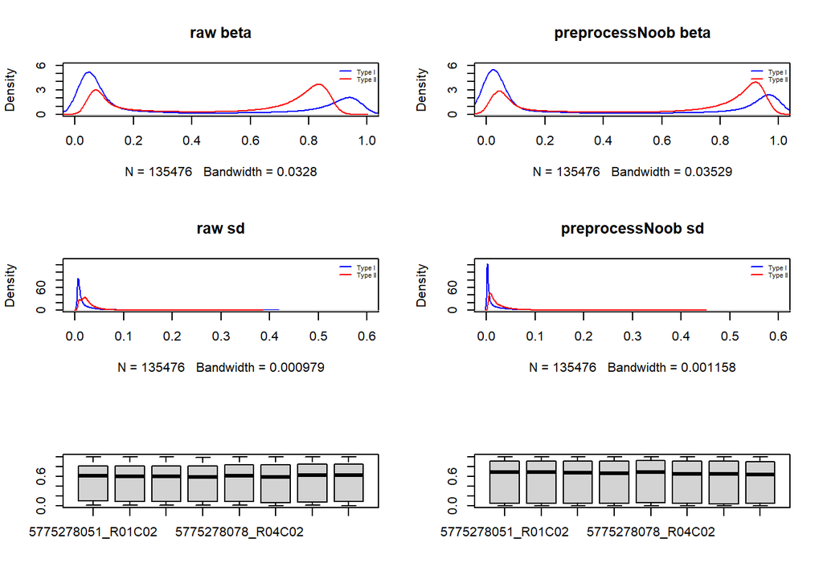

```r
par(mfrow=c(3,2))
# For raw mean beta:
plot(d_mean_of_beta_I,col="blue",main="raw beta",xlim=c(0,1),ylim=c(0,6))
lines(d_mean_of_beta_II,col="red")
legend("topright", legend=c("Type I", "Type II"), col=c("blue", "red"), lwd=1:1, cex=0.5, bty="n")

# For normalized mean beta:
plot(d_mean_of_preprocessNoob_results_beta_I,col="blue",main="preprocessNoob beta",xlim=c(0,1),ylim=c(0,6))
lines(d_mean_of_preprocessNoob_results_beta_II,col="red")
legend("topright", legend=c("Type I", "Type II"), col=c("blue", "red"), lwd=1:1, cex=0.5, bty="n")

# For raw SD beta:
plot(d_sd_of_beta_I,col="blue",main="raw sd",xlim=c(0,0.6),ylim=c(0,130))
lines(d_sd_of_beta_II,col="red")
legend("topright", legend=c("Type I", "Type II"), col=c("blue", "red"), lwd=1:1, cex=0.5, bty="n")

# For normalized SD beta:
plot(d_sd_of_preprocessNoob_results_beta_I,col="blue",main="preprocessNoob sd",xlim=c(0,0.6),ylim=c(0,130))
lines(d_sd_of_preprocessNoob_results_beta_II,col="red")
legend("topright", legend=c("Type I", "Type II"), col=c("blue", "red"), lwd=1:1, cex=0.5, bty="n")

# For raw beta boxplot:
boxplot(beta,ylim=c(0,1))

# For normalized beta boxplot:
boxplot(preprocessNoob_results_beta,ylim=c(0,1))
```

Enlarged:

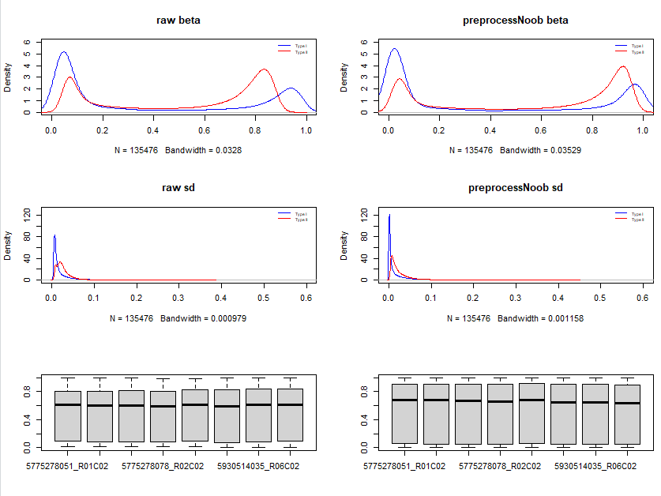

❖ In both top graphs, we see that we have a great difference between probe types, the peak of type I is higher at low methylation levels and the peak of type II is higher at high methylation level, mainly because of the differences of the regions that these two different types are meant to analyse, because as we may know, type II is generally used for sites distant from CpG sites while type I forms a slight majority in CGI sites only (still present in shores and distant regions but not in sizeable amounts). Usually, density of beta values from type II is shifted towards the center and so it is not suitable for detection of extreme methylation values, solution is that by applying the correction, we can have the same profiles with the same peaks, so rescaling in topright graph in which the peak has moved to the right.

❖ In the middle two graphs, we can see that when the peak has become sharper and longer and the standard deviation has been reduced, they are both slightly shifted to lower values as well.

❖ In the bottom two graphs, we can see the data has been somehow centered, the interquartile range has increased as well and the variation decreased, data has been normalised to ensure that the distributions on each of the arrays are somehow identical.

## 8- Perform a PCA on the beta matrix generated in step 7. Comment the plot.

The idea behind PCA is to explore correlations between samples/conditions or genes (variables). PCA is recommended as an exploratory tool to uncover unknown trends in the data. To identify variance components.

Our matrix has samples in columns and CpG probes in rows: the **prcomp()** function should be applied to the transposed matrix, which is achieved using the **t()** function:

```r
pca_results <- prcomp(t(preprocessNoob_results_beta),scale=T)
print(summary(pca_results))
```

```
## Importance of components:
##                             PC1      PC2      PC3      PC4      PC5       PC6
## Standard deviation     369.2054 269.9815 252.9972 245.2224 239.5624 220.22158
## Proportion of Variance   0.2808   0.1501   0.1318   0.1239   0.1182   0.09989
## Cumulative Proportion    0.2808   0.4309   0.5627   0.6866   0.8048   0.90468
##                              PC7       PC8
## Standard deviation     215.12809 5.504e-12
## Proportion of Variance   0.09532 0.000e+00
## Cumulative Proportion    1.00000 1.000e+00
```

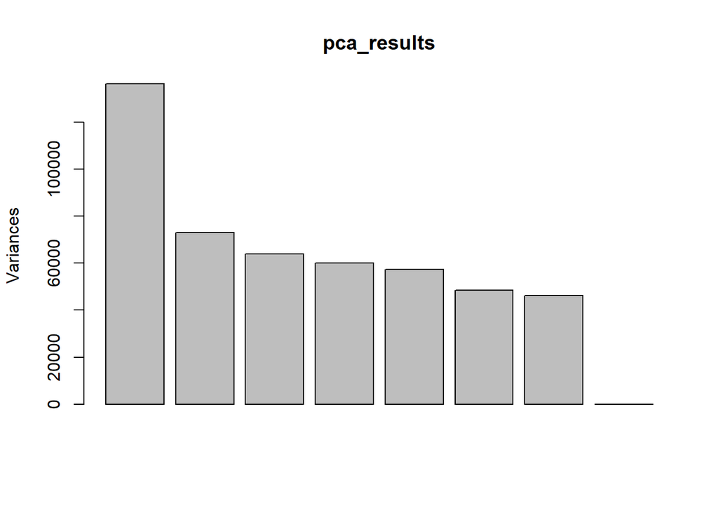

```r
plot(pca_results)
```

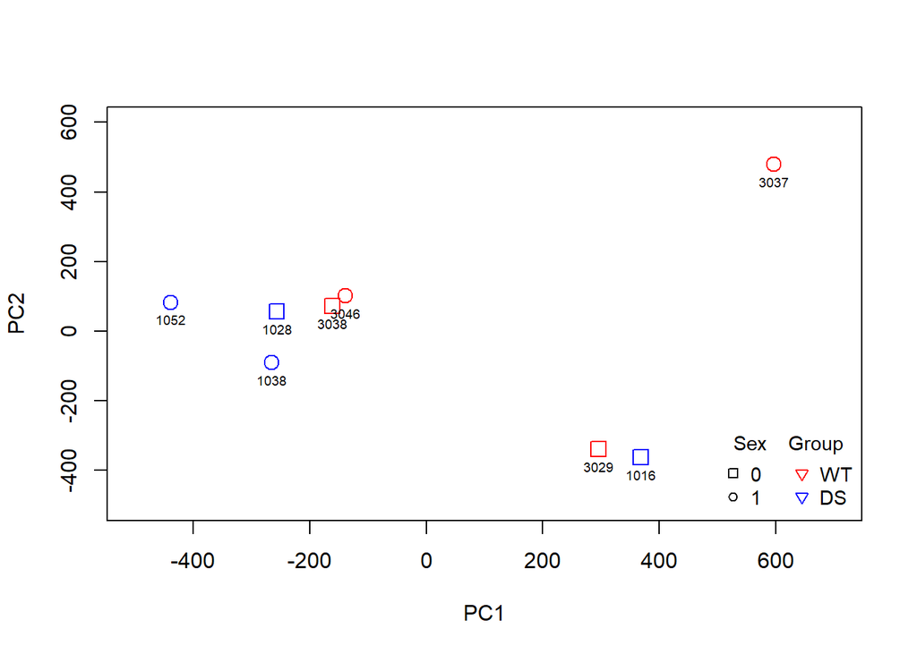

```r
palette(c("blue","red"))

plot(pca_results$x[,1], pca_results$x[,2],cex=1.5,pch=SampleSheet$Sex,col=factor(SampleSheet$Group),xlab="PC1",ylab="PC2",xlim=c(-500,700),ylim=c(-500,600))
# plot name of samples
text(pca_results$x[,1], pca_results$x[,2],labels=SampleSheet$Sample_Name,cex=0.6,pos=1)
legend("bottomright", title="Sex    Group", legend=c("0","1","WT","DS"), col=c("black", "black", 'red','blue'), pch=c(0,1,6,6), bty="n", border=T, ncol=2, cex=0.9)
```

With that few number of samples, the plot will not be so informative, however, there seems to be a very slight trend of the wild type having higher PC1 values. Nevertheless, an advisable approach is that this needs to be verified using higher number of samples if possible.

## 9- Using the matrix of normalized beta values generated in step 7, identify differentially methylated probes between group DS and group WT using the function assigned to each student. Note; it can take several minutes; if you encounter any problem you can run the differential methylation analysis only on a subset of probes (for example those on chromosome 1, 18 and 21)

❖ Our aim is to identify the CpG probes that are differentially methyled between samples belonging to groups “DS” and “WT”. We will use a parametric test (t-test). Which performs one and two sample t-tests on vectors of data. we calculate the pvalue and if it is lower than our confidence threshold, the alternative hypothesis can be accepted and the null hypothesis to be rejected. We will use the t-test to compare the first CpG of **beta_preprocessNoob** between groups DS and WT:

```r
t_test <- t.test(preprocessNoob_results_beta[1,] ~ SampleSheet$Group)
t_test
```

```
##
##  Welch Two Sample t-test
##
## data:  preprocessNoob_results_beta[1, ] by SampleSheet$Group
## t = 0.028447, df = 5.9989, p-value = 0.9782
## alternative hypothesis: true difference in means between group DS and group WT is not equal to 0
## 95 percent confidence interval:
##  -0.3807992  0.3897570
## sample estimates:
## mean in group DS mean in group WT
##        0.8140893        0.8096103
```

❖ We will use the **apply()** function to calculate the mean of each row of the matrix. However, unlike the **mean()** function, **t.test()** functions does not return a value, but a list; therefore, we have to create an ad hoc function:

```r
My_ttest_function <- function(x) {
   t_test <- t.test(x~ SampleSheet$Group)
   return(t_test$p.value)
}
pValues_ttest <- apply(preprocessNoob_results_beta,1, My_ttest_function)
save(pValues_ttest,file="t-testpvalues.RData")
summary(pValues_ttest)
```

```
##      Min.   1st Qu.    Median      Mean   3rd Qu.      Max.
## 0.0000001 0.2345587 0.4720923 0.4835648 0.7308799 0.9999988
```

❖ Now, we have to create a dataframe with the pvalue for each probe and beta values:

```r
ttest_pvalues_and_beta <- data.frame(preprocessNoob_results_beta, pValues_ttest)
```

❖ We can order the probes on the basis of the pValues column (from the smallest to the largest value):

```r
ttest_pvalues_and_beta <- ttest_pvalues_and_beta[order(ttest_pvalues_and_beta$pValues_ttest),]
head(ttest_pvalues_and_beta)
```

```
##            X5775278051_R01C02 X5775278078_R01C01 X5775278078_R02C01
## cg09813647          0.3814193          0.3803793          0.8301712
## cg20242066          0.3636239          0.3996527          0.7525652
## cg01281157          0.3416555          0.3208705          0.1782497
## cg15482893          0.1187923          0.1201341          0.2179726
## cg20651389          0.5432598          0.5335881          0.7869479
## cg20208398          0.4352673          0.4541099          0.1706949
##            X5775278078_R02C02 X5775278078_R04C02 X5930514034_R01C02
## cg09813647          0.8327361          0.4184421          0.3767790
## cg20242066          0.7648586          0.3646597          0.3645688
## cg01281157          0.1909275          0.3480806          0.3396889
## cg15482893          0.2143691          0.1067412          0.1215607
## cg20651389          0.8159099          0.5446910          0.5000046
## cg20208398          0.1197992          0.4835702          0.4574672
##            X5930514035_R06C02 X5930514054_R06C01 pValues_ttest
## cg09813647          0.8143427          0.7974511  6.847717e-08
## cg20242066          0.8070943          0.7837769  4.050924e-07
## cg01281157          0.1862785          0.2009653  1.671410e-06
## cg15482893          0.2218272          0.2036963  1.708334e-06
## cg20651389          0.8040432          0.8401198  1.728225e-06
## cg20208398          0.1334759          0.1653003  1.751048e-06
```

```r
summary(ttest_pvalues_and_beta)
```

```
##  X5775278051_R01C02 X5775278078_R01C01 X5775278078_R02C01 X5775278078_R02C02
##  Min.   :0.005732   Min.   :0.005302   Min.   :0.005647   Min.   :0.00546
##  1st Qu.:0.054782   1st Qu.:0.052121   1st Qu.:0.053149   1st Qu.:0.05346
##  Median :0.679324   Median :0.681734   Median :0.670145   Median :0.65520
##  Mean   :0.520794   Mean   :0.521990   Mean   :0.519612   Mean   :0.51581
##  3rd Qu.:0.908359   3rd Qu.:0.909685   3rd Qu.:0.908773   3rd Qu.:0.90546
##  Max.   :0.994895   Max.   :0.994649   Max.   :0.994891   Max.   :0.99442
##  X5775278078_R04C02 X5930514034_R01C02 X5930514035_R06C02 X5930514054_R06C01
##  Min.   :0.005699   Min.   :0.00649    Min.   :0.006037   Min.   :0.006198
##  1st Qu.:0.058762   1st Qu.:0.04577    1st Qu.:0.043418   1st Qu.:0.050020
##  Median :0.683159   Median :0.64924    Median :0.646135   Median :0.631748
##  Mean   :0.527258   Mean   :0.51093    Mean   :0.509138   Mean   :0.508669
##  3rd Qu.:0.915311   3rd Qu.:0.90540    3rd Qu.:0.907018   3rd Qu.:0.894390
##  Max.   :0.994783   Max.   :0.99383    Max.   :0.994496   Max.   :0.993947
##  pValues_ttest
##  Min.   :0.0000001
##  1st Qu.:0.2345587
##  Median :0.4720923
##  Mean   :0.4835648
##  3rd Qu.:0.7308799
##  Max.   :0.9999988
```

```r
length(pValues_ttest)
```

```
## [1] 485512
```

❖ Now, we need to specify how many probes have pValue<=0.05.

```r
final_ttest_0.05 <- ttest_pvalues_and_beta[ttest_pvalues_and_beta$pValues_ttest<=0.05,]
dim(final_ttest_0.05)[1]
```

```
## [1] 27102
```

The above results show that 27102 probes out of 485512 are actually above the significance threshold of 0.05. and this number is because generally (in small samples) parametric tests can lead to inaccurate p-values.

## 10- Apply multiple test correction and set a significant threshold of 0.05. How many probes do you identify as differentially methylated considering nominal pValues? How many after Bonferroni correction? How many after BH correction?

❖ We need to use Bonferroni for managing Family Wise Error Rate and Benjamin & Hochberg (BH) for False Discovery Rate, using the function **p.adjust** to adjust p-values in order to maintain the desired level of significance of the identified probe:

First of all, we will create a vector storing the p-values:

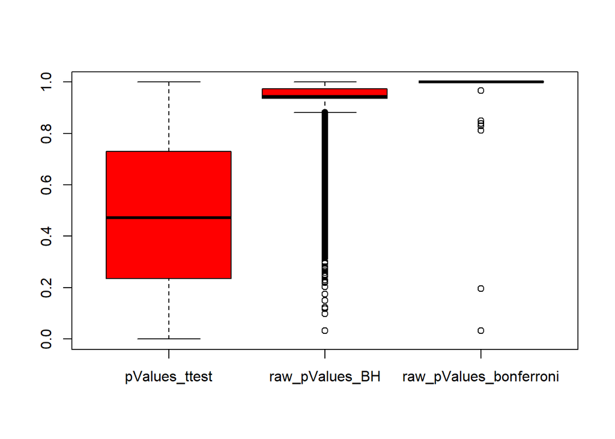

```r
raw_pValues <- ttest_pvalues_and_beta$pValues_ttest
raw_pValues_BH <- p.adjust(raw_pValues,"BH")
raw_pValues_bonferroni <- p.adjust(raw_pValues,"bonferroni")
corrected <- data.frame(ttest_pvalues_and_beta, raw_pValues_BH, raw_pValues_bonferroni)
boxplot(corrected[,9:11], col="red")
```

❖ Getting the significant probes:

```r
# Number of differentially methylated probes:
dim(corrected[corrected$pValues_ttest<=0.05,])[1]
```

```
## [1] 27102
```

```r
# After multiple correction:
corrected[corrected$raw_pValues_bonferroni<=0.05,][1]
```

```
##            X5775278051_R01C02
## cg09813647          0.3814193
```

```r
corrected[corrected$raw_pValues_BH<=0.05,][1]
```

```
##            X5775278051_R01C02
## cg09813647          0.3814193
```

Hence, only one pvalue in one probe of a sample was signficant after multiple test correction.

## 11- Produce a volcano plot and a Manhattan plot of the results of differential methylation analysis.

I- Volcano plot:

A volcano plot is constructed by plotting the negative log of the p value on the y axis (usually base 10). This results in data points with low p values (highly significant) appearing toward the top of the plot. The x axis is the log of the fold change between the two conditions. The plot also has areas to represent hyper and hypomethylation regions of the plot, usually on the topright (hyper) and topleft (hypo).

First, the difference between the average of group “WT” and “DS” values should be calculated. And to do that, we will have to create two matrices containing the beta-values of each group samples, and then we will calculate the mean within each group for each row, creating a dataframe with two columns, one containing the delta values and the other with the -log10 of p-values:

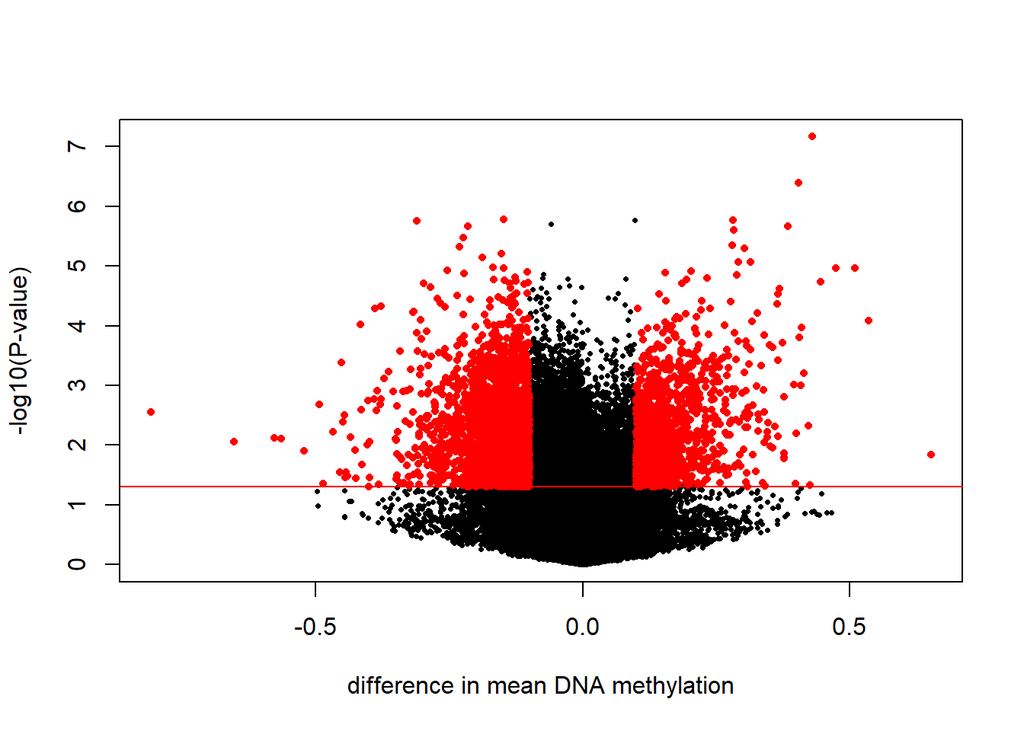

```r
corrected_WT <- corrected[,1:8][,SampleSheet$Group=="WT"]
corrected_DS <- corrected[,1:8][,SampleSheet$Group=="DS"]

corrected_WT_mean_beta <- apply(corrected_WT,1,mean)
corrected_DS_mean_beta <- apply(corrected_DS,1,mean)

corrected_diff_mean <- corrected_WT_mean_beta - corrected_DS_mean_beta

toVolcPlot <- data.frame(corrected_diff_mean, -log10(corrected$pValues_ttest))
plot(toVolcPlot[,1], toVolcPlot[,2],pch=16,cex=0.5,xlab="difference in mean DNA methylation", ylab="-log10(P-value)")
abline(h=-log10(0.05),col="red")
toHighlight <- toVolcPlot[abs(toVolcPlot[,1])>0.1 & toVolcPlot[,2]>(-log10(0.05)),]
points(toHighlight[,1], toHighlight[,2],pch=16,cex=0.7,col="red")
```

II- Manhattan plot:

Is a scatter plot which is similar to volcano plot with the difference is that we report on the x-axis the position on the genome according to chromosome. It helps to know if there are regions where there are clusters of differentially methylated probes.

First, we need to import the **qqman** library:

```r
library(qqman)
```

Second, we have to annotate our dataframe, that is add genome annotation information for each cpg probe. We will use the **Illumina450Manifest_clean** object that we previously created, then, We will use the **merge()** function to merge the **final_ttest_corrected** with the **Illumina450Manifest_clean** object.

```r
corrected <- data.frame(rownames(corrected), corrected)
colnames(corrected)[1] <- "IlmnID"

#basically merging the manifest with the corrected file
corrected_and_annotated <- merge(corrected, Illumina450Manifest_clean, by="IlmnID")
dim(corrected_and_annotated)
```

```
## [1] 485512     44
```

Now we can create the input for the Manhattan plot analysis. The input object should contain 4 parameters: probe, chromosome, position on the chromosome and p-value. We will select these columns in the **corrected_and_annotated** object:

```r
input_Manhattan_ttest <- corrected_and_annotated[colnames(corrected_and_annotated) %in% c("IlmnID","CHR","MAPINFO","pValues_ttest")]
levels(input_Manhattan_ttest$CHR)
```

```
##  [1] "1"  "10" "11" "12" "13" "14" "15" "16" "17" "18" "19" "2"  "20" "21" "22"
## [16] "3"  "4"  "5"  "6"  "7"  "8"  "9"  "X"  "Y"
```

```r
dim(input_Manhattan_ttest)
```

```
## [1] 485512      4
```

```r
head(input_Manhattan_ttest)
```

```
##       IlmnID pValues_ttest CHR   MAPINFO
## 1 cg00000029    0.02921934  16  53468112
## 2 cg00000108    0.99726179   3  37459206
## 3 cg00000109    0.08278805   3 171916037
## 4 cg00000165    0.30942107   1  91194674
## 5 cg00000236    0.62237693   8  42263294
## 6 cg00000289    0.46001446  14  69341139
```

It is better to reorder the levels of the column CHR:

```r
input_Manhattan_ttest$CHR <- factor(input_Manhattan_ttest$CHR,levels=c("1","2","3","4","5","6","7","8","9","10","11","12","13","14","15","16","17","18","19","20","21","22","X","Y"))
```

The column “CHR” should be numeric, hence, we will convert factors to numbers as follows:

```r
input_Manhattan_ttest$CHR <- as.numeric(input_Manhattan_ttest$CHR)
table(input_Manhattan_ttest$CHR)
```

```
##
##     1     2     3     4     5     6     7     8     9    10    11    12    13
## 46857 34810 25159 20464 24327 36611 30017 20950  9861 24388 28794 24539 12285
##    14    15    16    17    18    19    20    21    22    23    24
## 15078 15259 21969 27879  5922 25521 10379  4243  8552 11232   416
```

Producing the manhattan plot:

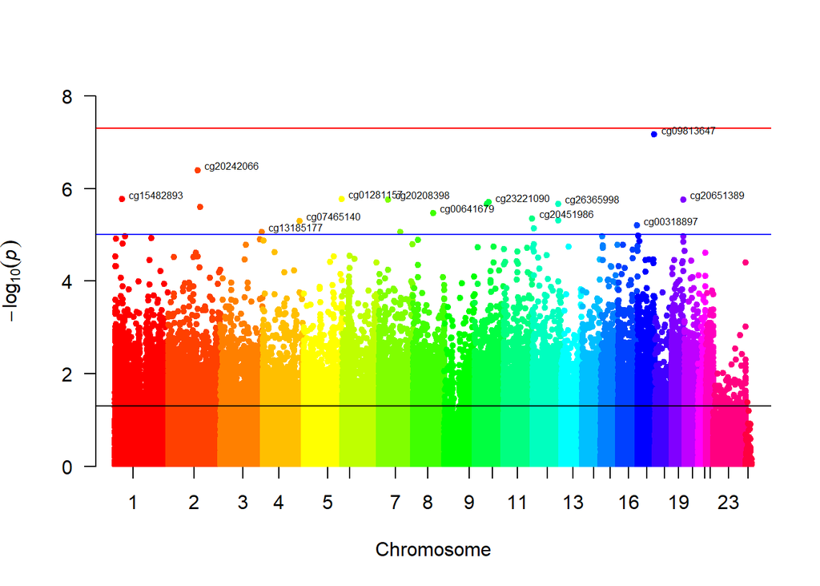

```r
manhattan(input_Manhattan_ttest, snp="IlmnID",chr="CHR", bp="MAPINFO", p="pValues_ttest",annotatePval = 0.00001,col=rainbow(24))
abline(h=-log10(0.05),col="black")
```

And here we got our Manhattan plot of differentially methylated positions in p values among chromosomes.

## 12- Produce an heatmap of the top 100 differentially mehtylated probes.

A heatmap is used as a graphical representation of data where the individual values contained in a matrix are represented as colors. It is a false color image (basically image(t(x))) with a dendrogram added to the left side and/or to the top. Typically, reordering of the rows and columns according to some set of values (row or column means) within the restrictions imposed by the dendrogram is carried out.

As an heatmap on several thousands of probes is computationally demanding, for our analysis we will use just the top 100 most significant CpG probes. We will extract only beta values for these top 100 probes and convert them in a matrix.

We will use the function **heatmap.2()** to visualize the heatmap, itt wants a matrix as an input:

Complete linkage:

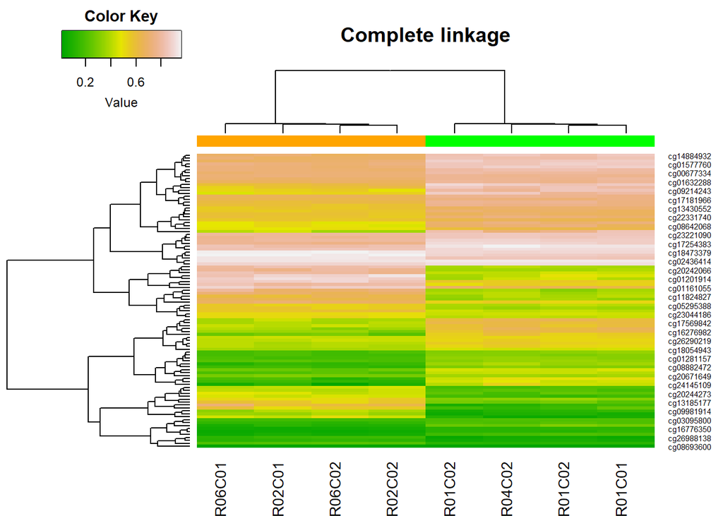

```r
library(gplots) # the library needed to do a heatmap
input_heatmap=as.matrix(final_ttest_0.05[1:100,1:8])
colorbar <- c("green","green","orange","orange","green","green","orange","orange")

heatmap.2(input_heatmap,col=terrain.colors(100),Rowv=T,Colv=T,dendrogram="both",key=T,ColSideColors=colorbar,density.info="none",trace="none",scale="none",symm=F,main="Complete linkage")
```

Single linkage:

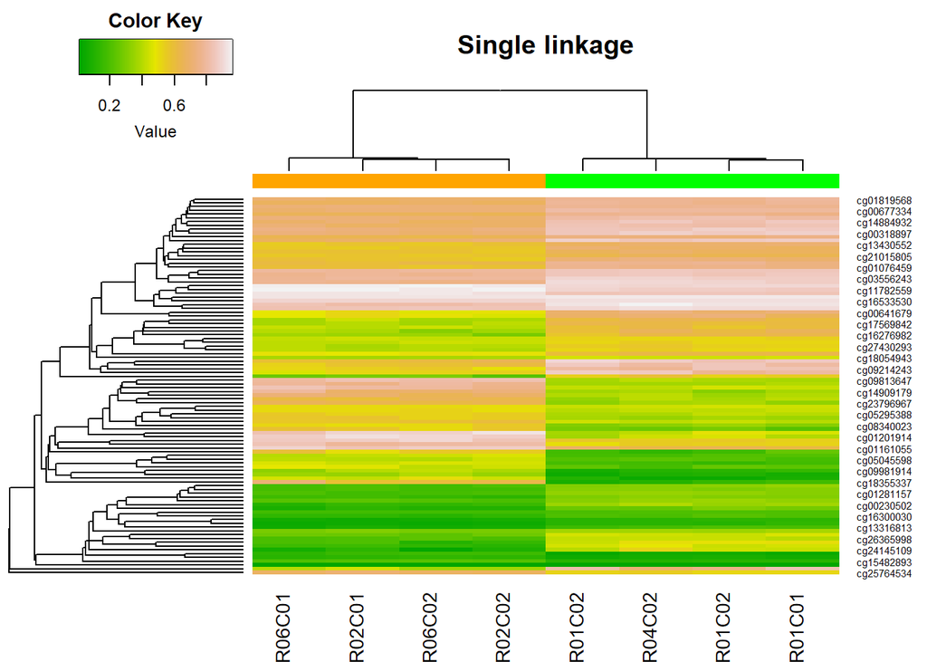

```r
heatmap.2(input_heatmap,col=terrain.colors(100),Rowv=T,Colv=T,hclustfun = function(x) hclust(x,method = 'single'),dendrogram="both",key=T,ColSideColors=colorbar,density.info="none",trace="none",scale="none",symm=F,main="Single linkage")
```

Average linkage:

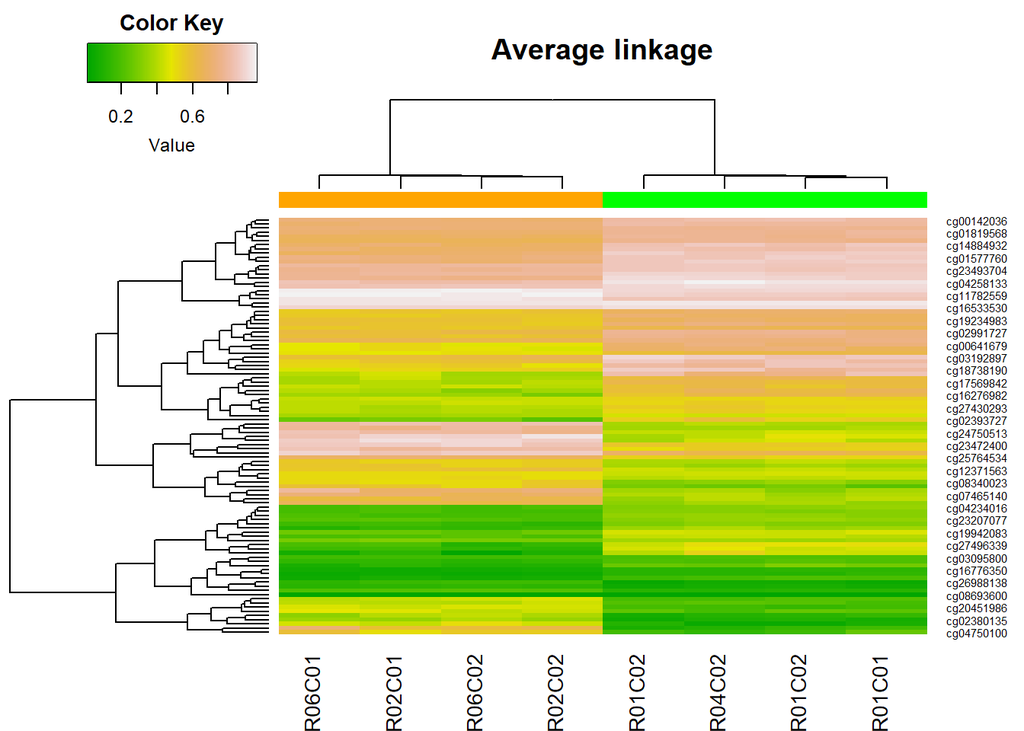

```r
heatmap.2(input_heatmap,col=terrain.colors(100),Rowv=T,Colv=T,hclustfun = function(x) hclust(x,method = 'average'),dendrogram="both",key=T,ColSideColors=colorbar,density.info="none",trace="none",scale="none",symm=F,main="Average linkage")
```

The figures affirm the difference between complete/average linkage approaches which perform better because the single linkage one suffers from long branches as what is evident. Yet still the average linkage approach is considered better among the two.

## 13- As DS is caused by the trisomy of chromosome 21, try also to plot the density of the methylation values of the probes mapping on chromosome 21. Do you see a very clear difference between the samples? How many differentially methylated probes do you find on chromosome 21?

❖ Using the corrected and annotated version:

```r
chr21_beta <- corrected_and_annotated[corrected_and_annotated$CHR==21,][,2:9]
```

❖ Dividing to DS and WT:

```r
WT_beta_chr_21  <- chr21_beta[,SampleSheet$Group=="WT"]
DS_beta_chr_21  <- chr21_beta[,SampleSheet$Group=="DS"]
```

❖ Creating mean and density distribution:

```r
mean_of_WT_beta_chr_21  <- apply(WT_beta_chr_21,1,mean,na.rm=T)
mean_of_DS_beta_chr_21  <- apply(DS_beta_chr_21,1,mean,na.rm=T)
d_mean_of_WT_beta_chr_21  <- density(mean_of_WT_beta_chr_21)
d_mean_of_DS_beta_chr_21  <- density(mean_of_DS_beta_chr_21)
```

❖ Plotting:

-on the 21st chromosome:

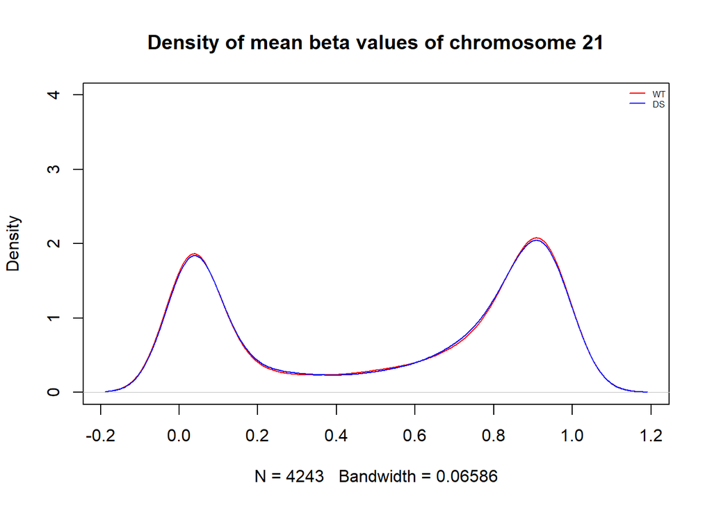

```r
plot(d_mean_of_WT_beta_chr_21,main="Density of mean beta values of chromosome 21",col="red", ylim=c(0,4))
lines(d_mean_of_DS_beta_chr_21,col="blue")
legend("topright", legend=c("WT", "DS"), col=c("red", "blue"), lwd=1:1, cex=0.5, bty="n")
```

From what is above, we can see that the density distributions are almost identical except for a very small difference, noticeable mostly in the righthand peak, nevertheless it can be considered negligible.

- Compared previous complete density distribution obtained in Question 6:

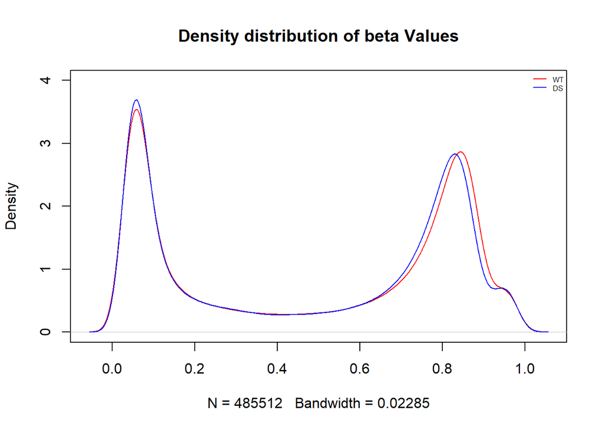

```r
plot(d_mean_of_WT_beta,main="Density distribution of beta Values",col="red", ylim=c(0,4))
lines(d_mean_of_DS_beta,col="blue")
legend("topright", legend=c("WT", "DS"), col=c("red", "blue"), lwd=1:1, cex=0.5, bty="n")
```

From what is above, we see that the peaks are lower with regards to chromosome 21.

Number of differetially meythylated probes on Chromosome 21:

```r
chr_21_beta_and_pvalues <- corrected_and_annotated[corrected_and_annotated$CHR==21,]
dim(chr_21_beta_and_pvalues[chr_21_beta_and_pvalues$pValues_ttest<=0.05,])[1]
```

```
## [1] 460
```